# ML-3 Mid_ExamPaper_40 Marks

### We combined two datasets in single CSV file. Use the below script to seperate the data.

#### Use data_clust for dimensionality reduction and clustering

#### Use data_recom for recommendation system.

import pandas as pd

data=pd.read_csv('dataset.csv')

data_clust=data.iloc[0:897,0:15]

data_recom=data.iloc[:,15:]

The column 'M3' talks about the relay postion, which is the target column. Don't use this while doing clustering and dimensionality reduction.

```python
import pandas as pd
import numpy as np
from sklearn.preprocessing import StandardScaler
import seaborn as sns
from matplotlib import pyplot as plt
from sklearn.cluster import KMeans
from sklearn.metrics import silhouette_score
from sklearn.decomposition import PCA
from sklearn.model_selection import train_test_split
from sklearn.ensemble import RandomForestClassifier
from sklearn.metrics import classification_report
```

```python
import warnings
warnings.filterwarnings("ignore")
```

# Section A - 5 Marks

### 1. Data Preprocessing

1a. Read the dataset and perform required cleaning and preprocessing prior to model building. Justify the pre-processing approaches used.(3 Marks)

1b. Perform atleast one univariate and bivariate analysis for the data_clust (2 Marks)

1c. Keep the input features of data_clust (independent variables) in the variable "inp_data_dime: and output feature (M3) in te variable out.

```python
data=pd.read_csv('dataset.csv')

data_clust=data.iloc[0:897,0:15]

data_recom=data.iloc[:,15:]
```

```python
data_clust[data_clust['M3'] == 'LOWER']
```

|  | N1 | N2 | N3 | N4 | N5 | N6 | N7 | N8 | N9 | N10 | N11 | N12 | N13 | N14 | M3 |
| --- | --- | --- | --- | --- | --- | --- | --- | --- | --- | --- | --- | --- | --- | --- | --- |
| 332 | 0.1021 | 0.0001 | 8.683489 | 0.291037 | 10.533904 | -2.535937 | 28.8001 | 21.6001 | 0.972371 | 0.122283 | -2.474795 | -0.433817 | 8.741696 | 6.328043 | LOWER |

```python
data_clust['N5']
```

```
0      10.533904
1      10.533904
2      10.533904
3      10.533904
4      10.533904
         ...
892    10.533904
893    10.533904
894    10.533904
895    10.533904
896    10.533904
Name: N5, Length: 897, dtype: float64
```

```python
def remove_outliers_iqr(df):
    Q1 = df.quantile(0.25)
    Q3 = df.quantile(0.75)
    IQR = Q3 - Q1
    outlier_mask = (df < (Q1 - 1.5 * IQR)) | (df > (Q3 + 1.5 * IQR))
    df_no_outliers = df[~outlier_mask.any(axis=1)]
    return df_no_outliers
```

```python
data_recom.isnull().sum()
```

```
userId       0
productId    0
Rating       0
dtype: int64
```

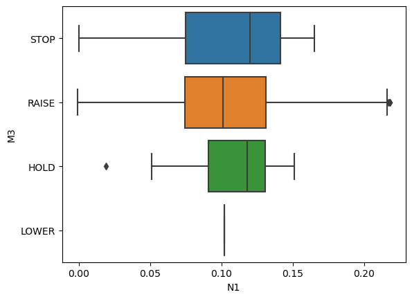

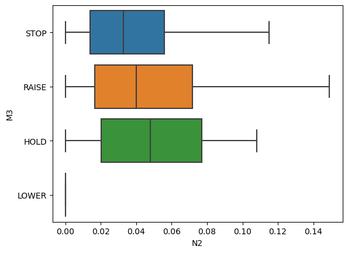

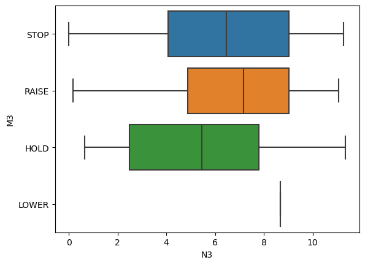

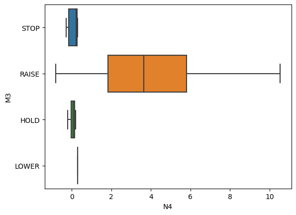

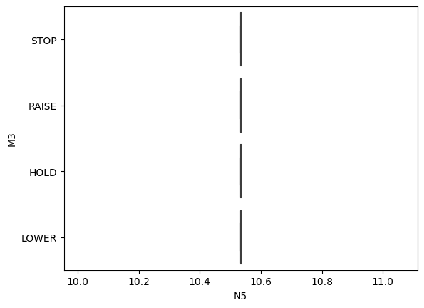

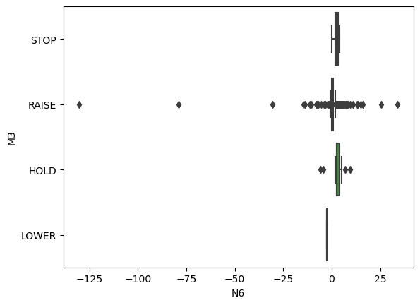

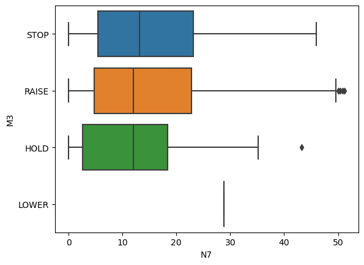

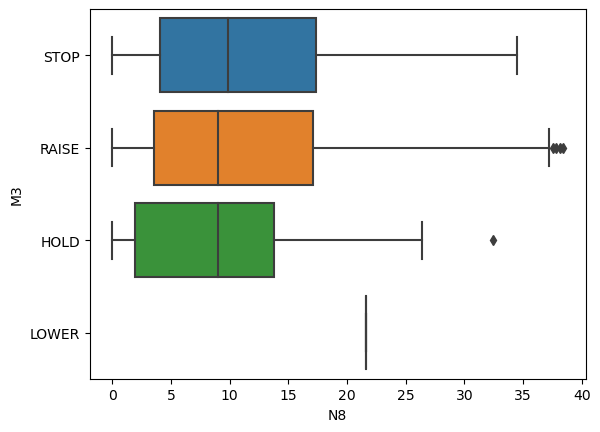

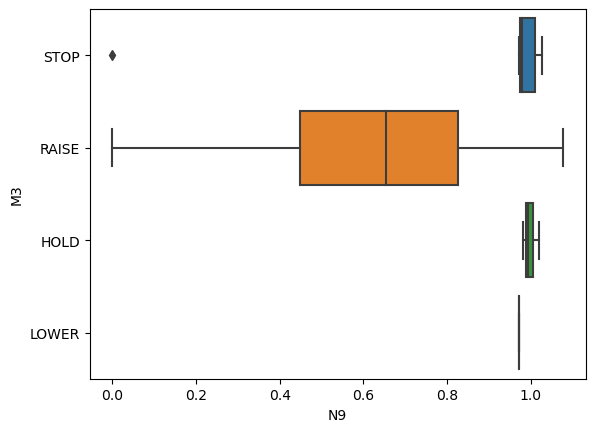

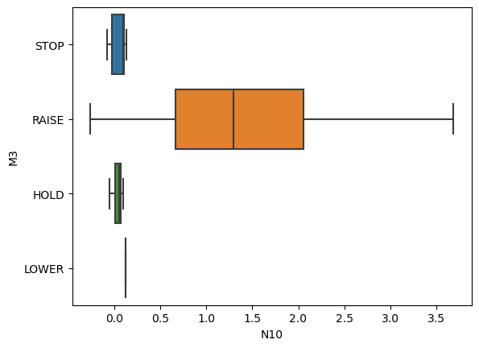

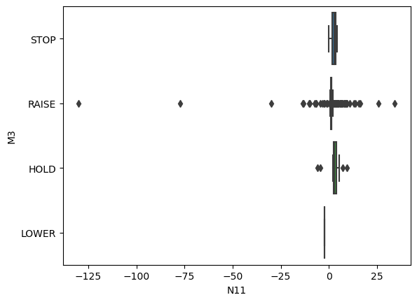

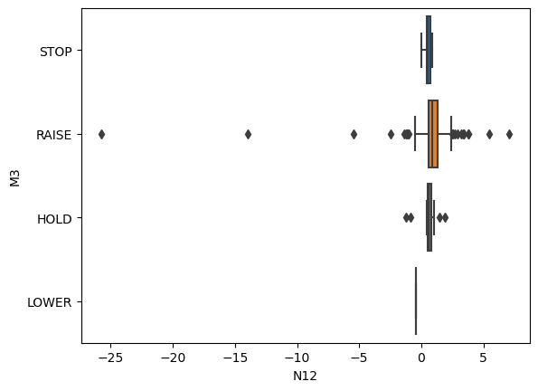

[2 more figures not shown]

```python
for i in data_clust.drop('M3',axis=1).columns:
    sns.boxplot(x = data_clust[i],y = data_clust['M3'])
    plt.show()
```

```python
data_clust = remove_outliers_iqr(data_clust)
```

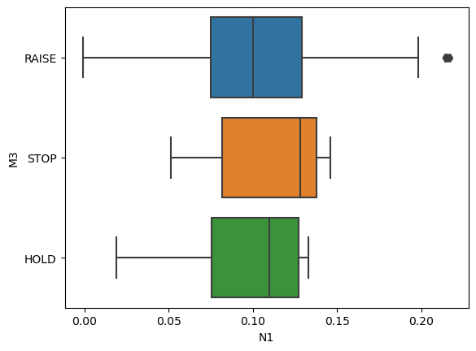

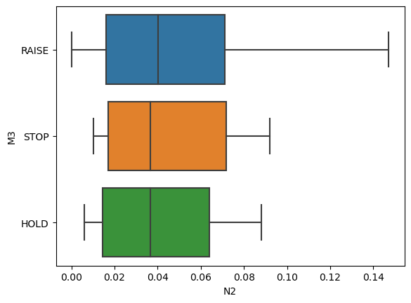

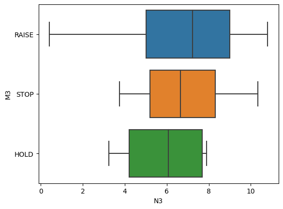

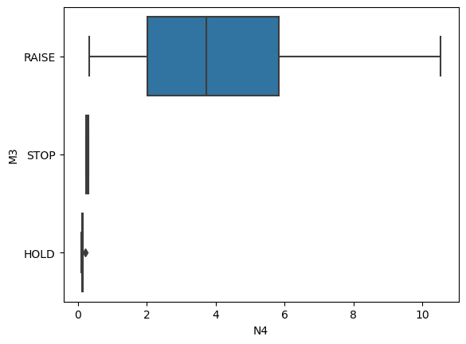

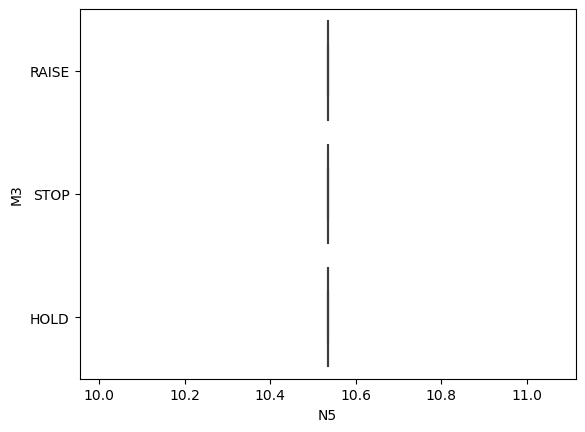

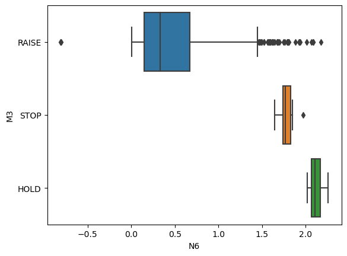

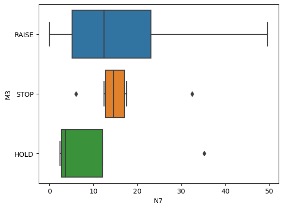

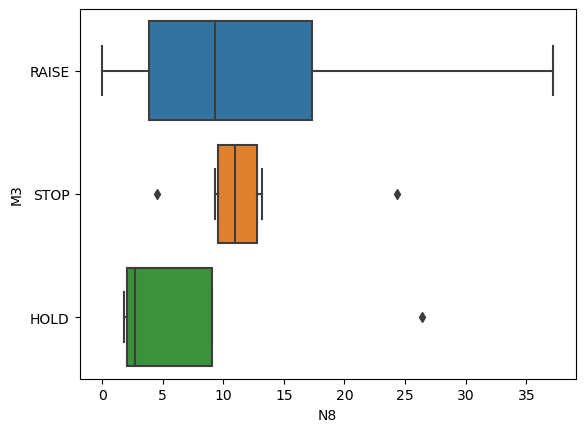

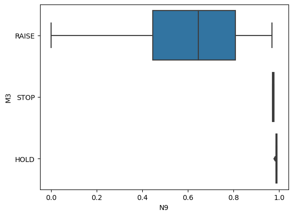

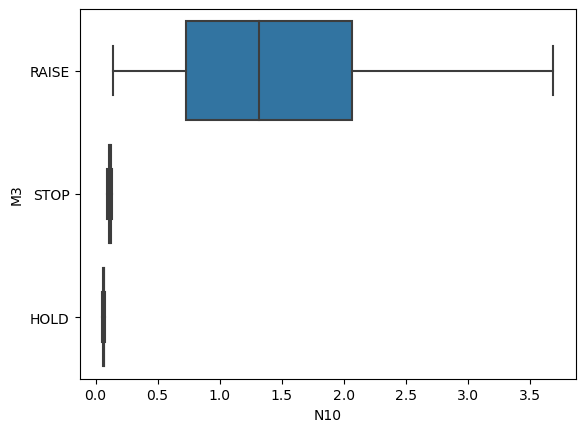

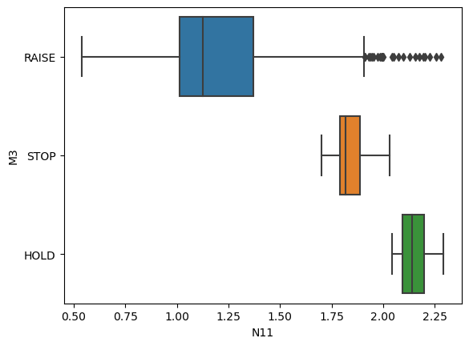

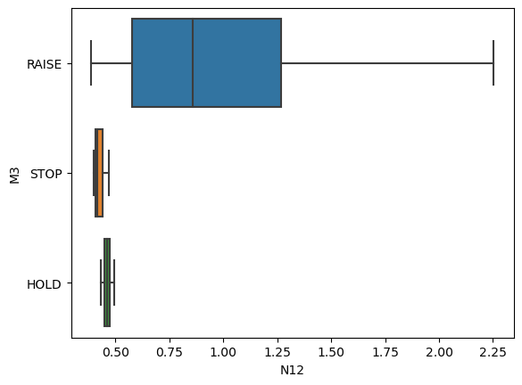

[2 more figures not shown]

```python
for i in data_clust.drop('M3',axis=1).columns:
    sns.boxplot(x = data_clust[i],y = data_clust['M3'])
    plt.show()
```

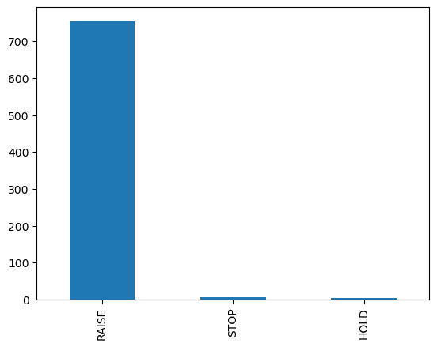

```python
data_clust['M3'].value_counts().plot(kind='bar')
```

```python
data_clust['M3'].value_counts()
```

```
RAISE    754
STOP       6
HOLD       4
Name: M3, dtype: int64
```

```python
inp_data_dime=data_clust.drop('M3',axis=1)
out=data_clust['M3']
```

```python
from sklearn.preprocessing import StandardScaler
scaler = StandardScaler()
data_sc = scaler.fit_transform(inp_data_dime)
data_sc=pd.DataFrame(data_sc,columns=inp_data_dime.columns)
```

```python
inp_data_dime.describe()
```

|  | N1 | N2 | N3 | N4 | N5 | N6 | N7 | N8 | N9 | N10 | N11 | N12 | N13 | N14 |
| --- | --- | --- | --- | --- | --- | --- | --- | --- | --- | --- | --- | --- | --- | --- |
| count | 764.000000 | 764.000000 | 764.000000 | 764.000000 | 7.640000e+02 | 764.000000 | 764.000000 | 764.000000 | 764.000000 | 764.000000 | 764.000000 | 764.000000 | 764.000000 | 764.000000 |
| mean | 0.102241 | 0.046859 | 6.832370 | 4.070821 | 1.053390e+01 | 0.507970 | 15.325196 | 11.493913 | 0.613551 | 1.445236 | 1.230588 | 0.968735 | 7.646534 | 9.599740 |
| std | 0.040001 | 0.035163 | 2.509569 | 2.527691 | 1.955273e-13 | 0.486035 | 12.166306 | 9.124716 | 0.239958 | 0.884365 | 0.288256 | 0.455331 | 2.038017 | 1.572115 |
| min | -0.000900 | 0.000100 | 0.406897 | 0.095733 | 1.053390e+01 | -0.809031 | 0.000100 | 0.000100 | 0.000009 | 0.052327 | 0.539187 | 0.387555 | 2.437035 | 5.129894 |
| 25% | 0.075100 | 0.016100 | 5.017353 | 1.954831 | 1.053390e+01 | 0.157990 | 5.200100 | 3.900100 | 0.448567 | 0.698967 | 1.012914 | 0.569861 | 6.171923 | 8.433748 |
| 50% | 0.100600 | 0.039600 | 7.224992 | 3.676970 | 1.053390e+01 | 0.340549 | 12.400100 | 9.300100 | 0.650939 | 1.309681 | 1.128186 | 0.850509 | 7.950059 | 9.634533 |
| 75% | 0.129350 | 0.071100 | 8.986316 | 5.808741 | 1.053390e+01 | 0.709147 | 22.900100 | 17.175100 | 0.814425 | 2.057857 | 1.384071 | 1.264381 | 9.398242 | 10.794191 |
| max | 0.217100 | 0.147100 | 10.795990 | 10.533804 | 1.053390e+01 | 2.254982 | 49.600100 | 37.200100 | 0.990912 | 3.686851 | 2.291690 | 2.252111 | 10.937540 | 12.946697 |

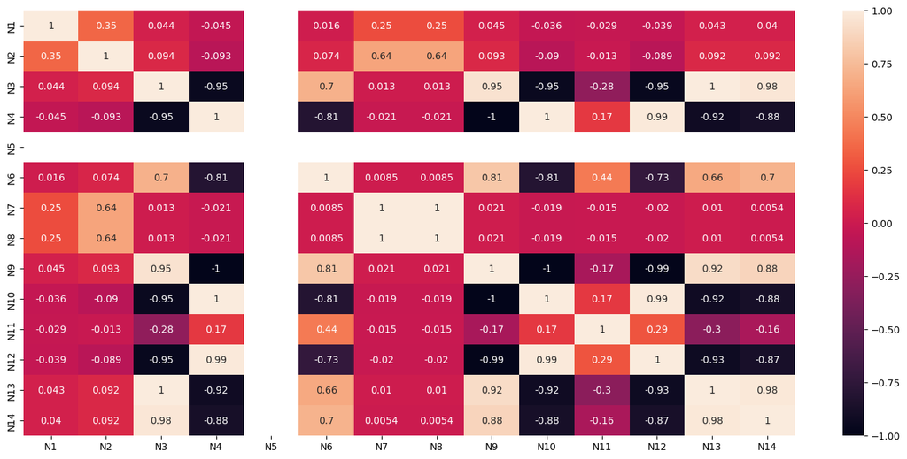

```python
import seaborn as sb
from matplotlib import pyplot as plt
plt.figure(figsize=(18,8))
sns.heatmap(inp_data_dime.corr(),annot=True)
```

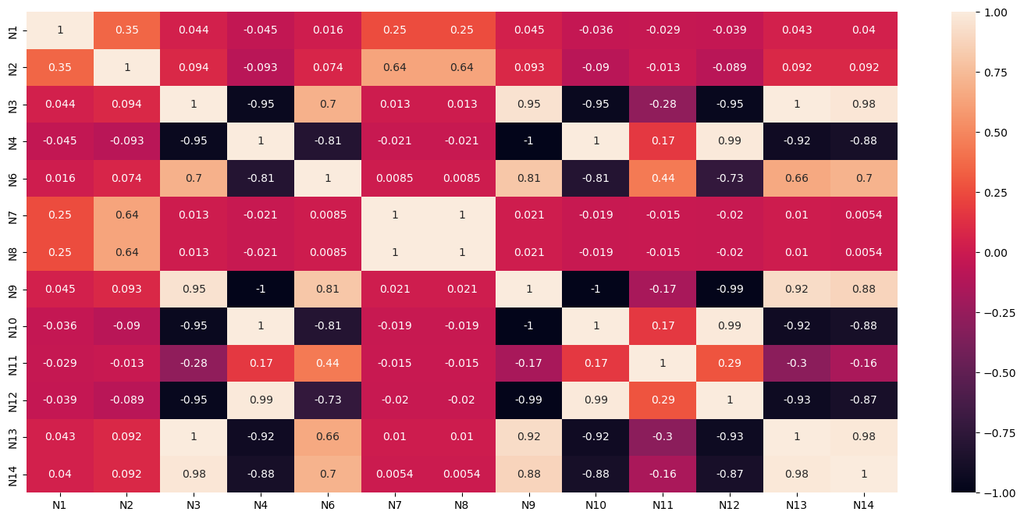

```python
inp_data_dime = inp_data_dime.drop('N5',axis = 1)
plt.figure(figsize=(18,8))
sns.heatmap(inp_data_dime.corr(),annot=True)
```

# Section B - 10 Marks

### 2. Apply K means clustering and identify the ideal value of K using elbow and silhoutee method

```
9932.0
5890.030608378187
4763.534769038962
3943.606991222756
3425.8687900856635
3047.0672697763666
2795.6935405572012
2612.942013018267
2290.884428073506
2037.6070079247454
```

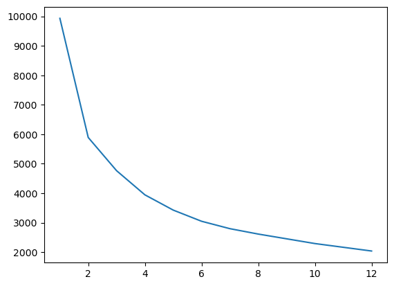

```python
from sklearn.cluster import KMeans
wcss=[]
cl=[1,2,3,4,5,6,7,8,10,12]
for i in cl:
    mod=KMeans(n_clusters=i,random_state=10)
    mod.fit(data_sc)
    print(mod.inertia_)
    wcss.append(mod.inertia_)
plt.plot(cl,wcss)
```

```python
sil=[]
from sklearn.metrics import silhouette_score
cl=[2,3,4,5,6,7,8]
for i in cl:
    mod=KMeans(n_clusters=i)
    mod.fit(data_sc)
    sil.append(silhouette_score(data_sc,mod.labels_))
res=pd.DataFrame({'k':cl,'silhoutee':sil})
res
```

|  | k | silhoutee |
| --- | --- | --- |
| 0 | 2 | 0.359696 |
| 1 | 3 | 0.270487 |
| 2 | 4 | 0.285697 |
| 3 | 5 | 0.254764 |
| 4 | 6 | 0.260316 |
| 5 | 7 | 0.266762 |
| 6 | 8 | 0.242572 |

# Section C - 10 Marks

### 3. Apply PCA on the data. How many PCs are required to reproduce the 95% charecteristics of original data. What is the top 5 features contributing in PC1 ?(5 marks)

### 4. Build the following ML model and compare its performace: (5 Marks)

```
a. ML model with original inp_data_dime and out
b. ML model with inp_data_dime_pca and out

(Note: the pca components (inp_data_dime_pca) must capture the 95 percent varaince in the data)
```

```python
from sklearn.decomposition import PCA
pca = PCA(n_components = data_sc.shape[1])
pca_data = pca.fit_transform(data_sc)
exp_var_ratio= pca.explained_variance_ratio_
exp_var_ratio.round(3)

cum_var=exp_var_ratio[0]
itr=2 # defined as two as first pc1 variance defined outside the loop
for j in exp_var_ratio[1:]:
    cum_var=cum_var+j
    if cum_var >= 0.95:
        break
    itr=itr+1

print('The number of principle components capturing 95 percent varaition is data is : ',itr,' Varaince explained is ', cum_var)
```

```
The number of principle components capturing 95 percent varaition is data is :  5  Varaince explained is  0.9775264729179419
```

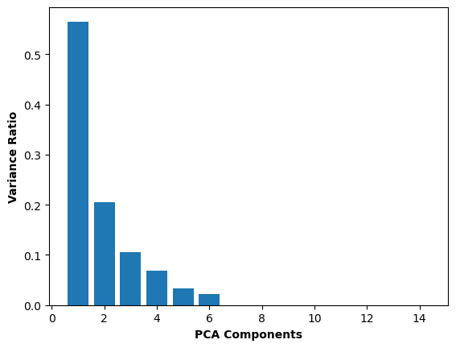

```python
# Variance Ratio bar plot for each PCA components.
ax = plt.bar(range(1,len(pca.explained_variance_ratio_)+1), pca.explained_variance_ratio_)
plt.xlabel("PCA Components",fontweight = 'bold')
plt.ylabel("Variance Ratio",fontweight = 'bold')
```

```python
# PC1 is derived from first eigen vector
e1=pd.DataFrame(pca.components_[0,:]) # first eigen vector
e1.index=data_sc.columns
e11=np.abs(e1)
e11.sort_values(0,ascending=False).head(5) # Top 5 features contributing in PC1
```

|  | 0 |
| --- | --- |
| N4 | 0.364519 |
| N9 | 0.364519 |
| N10 | 0.364462 |
| N12 | 0.362300 |
| N3 | 0.362168 |

```python
### 5. Build the following ML model and compare its performace: (5 Marks)
    #a. ML model with original inp_data_dime and out
    #b. ML model with inp_data_dime_pca and out
    #(Note: For pca and svd use the number of components which captures the 95 percent of variance)

from sklearn.model_selection import train_test_split
from sklearn.ensemble import RandomForestClassifier
from sklearn.metrics import classification_report

xtrain,xtest,ytrain,ytest=train_test_split(data_sc,out,test_size=0.2,random_state=48)
rf=RandomForestClassifier(random_state=48)
rf.fit(xtrain,ytrain)
ypred=rf.predict(xtest)
print('The number of input feature ',xtrain.shape[1])
print(classification_report(ytest,ypred))
```

```
The number of input feature  14
              precision    recall  f1-score   support

       RAISE       1.00      1.00      1.00       152
        STOP       1.00      1.00      1.00         1

    accuracy                           1.00       153
   macro avg       1.00      1.00      1.00       153
weighted avg       1.00      1.00      1.00       153
```

```python
xtrain,xtest,ytrain,ytest=train_test_split(pca_data[:,:5],out,test_size=0.2,random_state=48)
rf=RandomForestClassifier(random_state=48)
rf.fit(xtrain,ytrain)
ypred=rf.predict(xtest)
print('The number of PCA components ',xtrain.shape[1])
print(classification_report(ytest,ypred))
```

```
The number of PCA components  5
              precision    recall  f1-score   support

       RAISE       0.99      1.00      1.00       152
        STOP       0.00      0.00      0.00         1

    accuracy                           0.99       153
   macro avg       0.50      0.50      0.50       153
weighted avg       0.99      0.99      0.99       153
```

# Section D - 15 Marks

### 5. Recommondation Systems

#### use data_recom

```python
from surprise import KNNWithMeans,SVDpp
from surprise import Dataset
from surprise import accuracy
from surprise import Reader
from surprise.model_selection import train_test_split,cross_validate
```

[output not shown]

```python
data_recom.head(2)
```

[output not shown]

```python
from surprise import KNNWithMeans,SVDpp
from surprise import Dataset
from surprise import accuracy
from surprise import Reader
from surprise.model_selection import train_test_split,cross_validate
#data_recom=pd.read_csv('recommendation_mini.csv')
ratings = data_recom
reader = Reader(rating_scale=(1, 5))
```